**Deep Learning for Mechanical Engineering**  
**FCN**

Instructor: Prof. Seungchul Lee  
http://iai.postech.ac.kr/  
Industrial AI Lab at POSTECH

# Problem 1: FCN

We studied FCN model with VGG16 network in class. Implement your FCN model using VGG19 network for encoder part of model and test it. I recommend to use colab rather than your laptop.

Download data from [here](https://www.dropbox.com/s/vst7ezw7qoafbux/PS08_data_files_segmentation.zip?dl=1)

We are going to use a pre-trained VGG network and apply the FCN model.

```python
# import library

import numpy as np
import matplotlib.pyplot as plt
import tensorflow as tf
import cv2
```

(1) Load segmented data using `numpy.load` function and print data shape.

- images_training.npy
- seg_training.npy
- images_testing.npy

```python
# Your code here
train_imgs = np.load('./data_files/images_training.npy')
train_seg = np.load('./data_files/seg_training.npy')
test_imgs = np.load('./data_files/images_testing.npy')

n_train = train_imgs.shape[0]
n_test = test_imgs.shape[0]

print ("The number of training images : {}, shape : {}".format(n_train, train_imgs.shape))
print ("The number of testing images : {}, shape : {}".format(n_test, test_imgs.shape))
```

```
The number of training images : 289, shape : (289, 160, 576, 3)
The number of testing images : 290, shape : (290, 160, 576, 3)
```

(2) Plot random image of train data set.

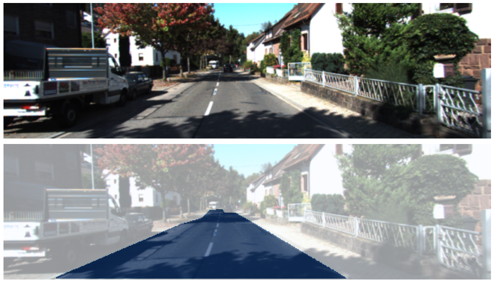

```python
# Your code here
idx = np.random.randint(n_train)

plt.figure(figsize = (16, 8))
plt.subplot(2,1,1); plt.axis('off')
plt.imshow(train_imgs[idx])
plt.subplot(2,1,2); plt.axis('off')
plt.imshow(train_imgs[idx])
plt.imshow(train_seg[idx][:, :, 1], cmap = 'Blues', alpha = 0.6)
plt.tight_layout()
plt.show()
```

(3) Load VGG19 network and print model structure.

- weights = 'imagenet'

```python
# Your code here
model_type = tf.keras.applications.vgg19
base_model = model_type.VGG19(weights = 'imagenet', include_top = False)
base_model.trainable = False
base_model.summary()
```

```
Downloading data from https://storage.googleapis.com/tensorflow/keras-applications/vgg19/vgg19_weights_tf_dim_ordering_tf_kernels_notop.h5
Model: "vgg19"
_________________________________________________________________
Layer (type)                 Output Shape              Param #
=================================================================
input_1 (InputLayer)         [(None, None, None, 3)]   0
_________________________________________________________________
block1_conv1 (Conv2D)        (None, None, None, 64)    1792
_________________________________________________________________
block1_conv2 (Conv2D)        (None, None, None, 64)    36928
_________________________________________________________________
block1_pool (MaxPooling2D)   (None, None, None, 64)    0
_________________________________________________________________
block2_conv1 (Conv2D)        (None, None, None, 128)   73856
_________________________________________________________________
block2_conv2 (Conv2D)        (None, None, None, 128)   147584
_________________________________________________________________
block2_pool (MaxPooling2D)   (None, None, None, 128)   0
_________________________________________________________________
block3_conv1 (Conv2D)        (None, None, None, 256)   295168
_________________________________________________________________
block3_conv2 (Conv2D)        (None, None, None, 256)   590080
_________________________________________________________________
block3_conv3 (Conv2D)        (None, None, None, 256)   590080
_________________________________________________________________
block3_conv4 (Conv2D)        (None, None, None, 256)   590080
_________________________________________________________________
block3_pool (MaxPooling2D)   (None, None, None, 256)   0
_________________________________________________________________
block4_conv1 (Conv2D)        (None, None, None, 512)   1180160
_________________________________________________________________
block4_conv2 (Conv2D)        (None, None, None, 512)   2359808
_________________________________________________________________
block4_conv3 (Conv2D)        (None, None, None, 512)   2359808
_________________________________________________________________
block4_conv4 (Conv2D)        (None, None, None, 512)   2359808
_________________________________________________________________
block4_pool (MaxPooling2D)   (None, None, None, 512)   0
_________________________________________________________________
block5_conv1 (Conv2D)        (None, None, None, 512)   2359808
_________________________________________________________________
block5_conv2 (Conv2D)        (None, None, None, 512)   2359808
_________________________________________________________________
block5_conv3 (Conv2D)        (None, None, None, 512)   2359808
_________________________________________________________________
block5_conv4 (Conv2D)        (None, None, None, 512)   2359808
_________________________________________________________________
block5_pool (MaxPooling2D)   (None, None, None, 512)   0
=================================================================
Total params: 20,024,384
Trainable params: 0
Non-trainable params: 20,024,384
_________________________________________________________________
```

Now, we've got pre-trained weights and biases. In the following problems, we are going to use the weights and biases from above.

(4) Define your FCN model using the weights and biases in problem (3).

```python
# Your code here
map5 = base_model.layers[-5].output


# sixth convolution layer
conv6 = tf.keras.layers.Conv2D(filters = 4096,
                               kernel_size = (7,7),
                               padding = 'SAME',
                               activation = 'relu', name = 'conv6')(map5)

# 1x1 convolution layers
fcn4 = tf.keras.layers.Conv2D(filters = 4096,
                              kernel_size = (1,1),
                              padding = 'SAME',
                              activation = 'relu', name = 'fcn4')(conv6)

fcn3 = tf.keras.layers.Conv2D(filters = 2,
                              kernel_size = (1,1),
                              padding = 'SAME',
                              activation = 'relu', name = 'fcn3')(fcn4)

# Upsampling layers
fcn2 =  tf.keras.layers.Conv2DTranspose(filters = 512,
                                        kernel_size = (4,4),
                                        strides = (2,2),
                                        padding = 'SAME')(fcn3)

fcn1 =  tf.keras.layers.Conv2DTranspose(filters = 256,
                                        kernel_size = (4,4),
                                        strides = (2,2),
                                        padding = 'SAME')(fcn2 + base_model.layers[-10].output)

output =  tf.keras.layers.Conv2DTranspose(filters = 2,
                                          kernel_size = (16,16),
                                          strides = (4,4),
                                          padding = 'SAME',
                                          activation = 'softmax')(fcn1 + base_model.layers[-15].output)

model = tf.keras.Model(inputs = base_model.inputs, outputs = output)
```

```python
model.summary()
```

```
Model: "model"
__________________________________________________________________________________________________
Layer (type)                    Output Shape         Param #     Connected to
==================================================================================================
input_1 (InputLayer)            [(None, None, None,  0
__________________________________________________________________________________________________
block1_conv1 (Conv2D)           (None, None, None, 6 1792        input_1[0][0]
__________________________________________________________________________________________________
block1_conv2 (Conv2D)           (None, None, None, 6 36928       block1_conv1[0][0]
__________________________________________________________________________________________________
block1_pool (MaxPooling2D)      (None, None, None, 6 0           block1_conv2[0][0]
__________________________________________________________________________________________________
block2_conv1 (Conv2D)           (None, None, None, 1 73856       block1_pool[0][0]
__________________________________________________________________________________________________
block2_conv2 (Conv2D)           (None, None, None, 1 147584      block2_conv1[0][0]
__________________________________________________________________________________________________
block2_pool (MaxPooling2D)      (None, None, None, 1 0           block2_conv2[0][0]
__________________________________________________________________________________________________
block3_conv1 (Conv2D)           (None, None, None, 2 295168      block2_pool[0][0]
__________________________________________________________________________________________________
block3_conv2 (Conv2D)           (None, None, None, 2 590080      block3_conv1[0][0]
__________________________________________________________________________________________________
block3_conv3 (Conv2D)           (None, None, None, 2 590080      block3_conv2[0][0]
__________________________________________________________________________________________________
block3_conv4 (Conv2D)           (None, None, None, 2 590080      block3_conv3[0][0]
__________________________________________________________________________________________________
block3_pool (MaxPooling2D)      (None, None, None, 2 0           block3_conv4[0][0]
__________________________________________________________________________________________________
block4_conv1 (Conv2D)           (None, None, None, 5 1180160     block3_pool[0][0]
__________________________________________________________________________________________________
block4_conv2 (Conv2D)           (None, None, None, 5 2359808     block4_conv1[0][0]
__________________________________________________________________________________________________
block4_conv3 (Conv2D)           (None, None, None, 5 2359808     block4_conv2[0][0]
__________________________________________________________________________________________________
block4_conv4 (Conv2D)           (None, None, None, 5 2359808     block4_conv3[0][0]
__________________________________________________________________________________________________
block4_pool (MaxPooling2D)      (None, None, None, 5 0           block4_conv4[0][0]
__________________________________________________________________________________________________
block5_conv1 (Conv2D)           (None, None, None, 5 2359808     block4_pool[0][0]
__________________________________________________________________________________________________
conv6 (Conv2D)                  (None, None, None, 4 102764544   block5_conv1[0][0]
__________________________________________________________________________________________________
fcn4 (Conv2D)                   (None, None, None, 4 16781312    conv6[0][0]
__________________________________________________________________________________________________
fcn3 (Conv2D)                   (None, None, None, 2 8194        fcn4[0][0]
__________________________________________________________________________________________________
conv2d_transpose (Conv2DTranspo (None, None, None, 5 16896       fcn3[0][0]
__________________________________________________________________________________________________
tf_op_layer_AddV2 (TensorFlowOp [(None, None, None,  0           conv2d_transpose[0][0]
                                                                 block4_conv1[0][0]
__________________________________________________________________________________________________
conv2d_transpose_1 (Conv2DTrans (None, None, None, 2 2097408     tf_op_layer_AddV2[0][0]
__________________________________________________________________________________________________
tf_op_layer_AddV2_1 (TensorFlow [(None, None, None,  0           conv2d_transpose_1[0][0]
                                                                 block3_conv1[0][0]
__________________________________________________________________________________________________
conv2d_transpose_2 (Conv2DTrans (None, None, None, 2 131074      tf_op_layer_AddV2_1[0][0]
==================================================================================================
Total params: 134,744,388
Trainable params: 121,799,428
Non-trainable params: 12,944,960
__________________________________________________________________________________________________
```

(5) Define loss and optimizer.

```python
# Your code here
adam = tf.keras.optimizers.Adam(lr = 0.00001, beta_1 = 0.9, beta_2 = 0.999, epsilon = None, decay = 0.0, amsgrad = False)

model.compile(optimizer = adam,
              loss = 'categorical_crossentropy',
              metrics = 'accuracy')
```

(6) Train the model. Highly recommand to use GPU or CoLab. (Train on CPU may take more than half an hour.)

```python
# Your code here
model.fit(train_imgs, train_seg, batch_size = 4, epochs = 5, verbose = 1)
```

```
<tensorflow.python.keras.callbacks.History at 0x23c5680a160>
```

(7) Test your model.

- Pick random test image.
- Segment it by your trained FCN model.
- Plot mask and test image at the same time.

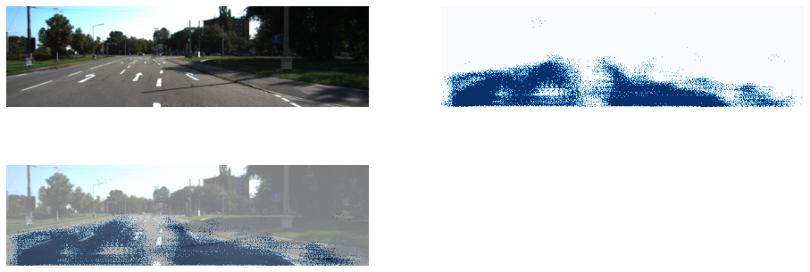

```python
# Your code here
test_x = test_imgs[[1]]
test_seg = model.predict(test_x)

seg_mask = (test_seg[:,:,:,1] > 0.5).reshape(160, 576, 1).astype(float)

plt.figure(figsize = (16,6))
plt.subplot(2,2,1)
plt.imshow(test_x[0])
plt.axis('off')
plt.subplot(2,2,2)
plt.imshow(seg_mask.reshape(160, 576), cmap = 'Blues')
plt.axis('off')
plt.subplot(2,2,3)
plt.imshow(test_x[0])
plt.imshow(seg_mask.reshape(160, 576), cmap = 'Blues', alpha = 0.5)
plt.axis('off')
plt.show()
```

(8) Now, we can segment images. Let's segment a highway image.

Download highway image from [here](https://www.dropbox.com/s/8t31fqlc5sorvtn/highway.png?dl=1)

- Load highway image
  - highway.png
- Print image shape (h, w, c)
- Segment it by your FCN model

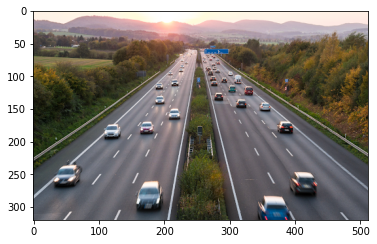

```python
# Your code here
import matplotlib.pyplot as plt
img_highway = plt.imread('PS08_data_files_segmentation/highway.png')
plt.imshow(img_highway)
plt.show()
img_highway = img_highway.reshape(-1,320,512,3)
```

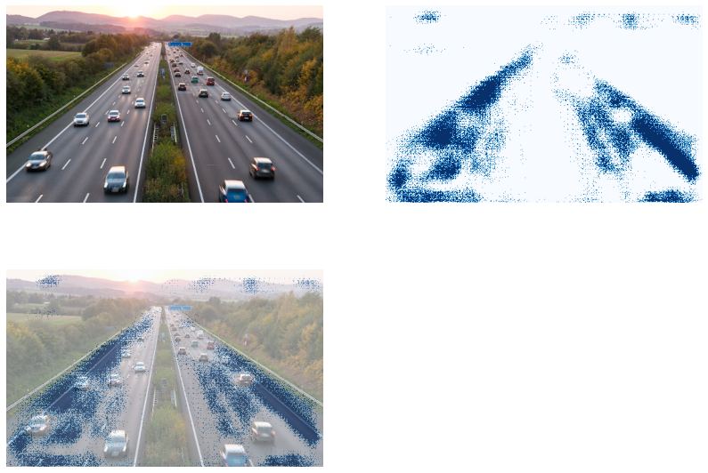

```python
# Your code here
test_x = img_highway
test_seg = model.predict(test_x)

seg_mask = (test_seg[:,:,:,1] > 0.5).reshape(320, 512, 1).astype(float)

plt.figure(figsize = (14,10))
plt.subplot(2,2,1)
plt.imshow(test_x[0])
plt.axis('off')
plt.subplot(2,2,2)
plt.imshow(seg_mask.reshape(320, 512), cmap = 'Blues')
plt.axis('off')
plt.subplot(2,2,3)
plt.imshow(test_x[0])
plt.imshow(seg_mask.reshape(320, 512), cmap = 'Blues', alpha = 0.5)
plt.axis('off')
plt.show()
```

(9) As you can see, the trained image and image in problem (8) have a different shape. Is it possible to input differently shaped images to the same FCN model without reshaping? If yes, explain why it is possible.

Answer)

Since FCN does not have a fully connected layer, the size of the input image does not matter.